# Chess Project

To clean the data, I ensured that I would only analyze ranked games instead of casual and ranked games. Afterwards, I filtered the games based on opening and then mutated the variables to ensure that all the openings that include the text would be seen. This was to ensure that games with variations attached, like “Nimzo-Larsen Attack _____ Variation” would still be included under the Nimzo-Larsen Attack umbrella. I then summarized the variables I wanted into new data frames to analyze the research questions.

## Visualization 1

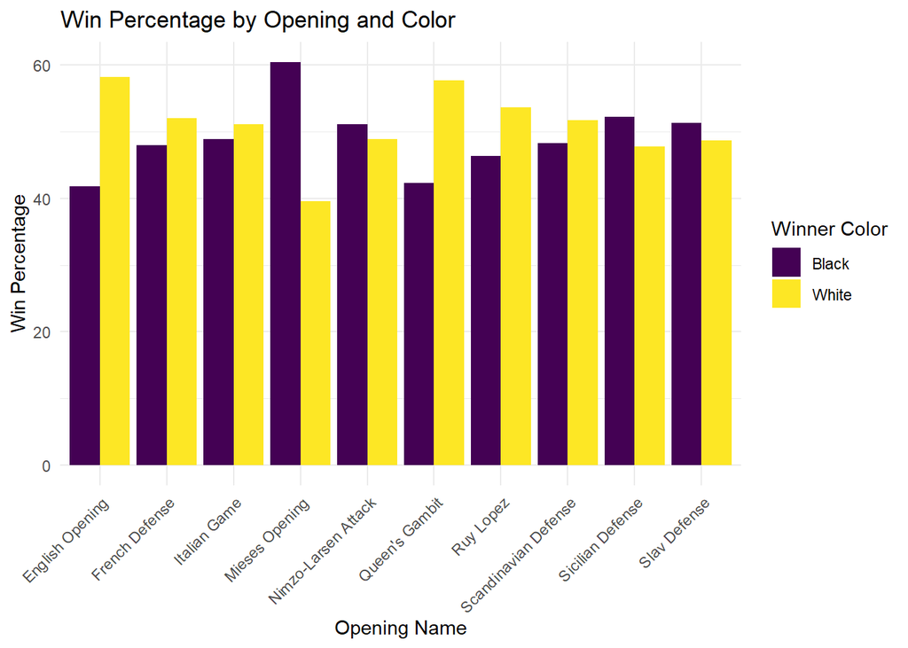

## Visualization 2

This visualization shows the type of Victory Status by the turn count. In chess, each player takes turns making a move. Each time a player completes 1 move each, that counts as 1 turn. So when 1 turn happens, both players have made a single move. In this visualization, we see that Resign has the lowest number of turns, meaning that people who are resigning often are doing so relatively early on in the game. This may be due to a million factors, but is often due to feeling as though they cannot win the game due to a poor position, and disadvantage. Next is Mate, which is short for Checkmate. Checkmate is when a player’s King can no longer make any legal move while simultaneously being attacked by a piece. This ends the game for the attacking player, who is declared victorious. Next, the variable Out of Time happens when a player loses because they did not make a move in time. Time formats are an extra factor in chess matches which add pressure to both players to perform quickly, or lose! Lastly, we see that games that end in draws often go on for very long. This is likely because games decided by draws often have far less pieces, therefore far less variables and possible outcomes on the chess board, and either end the game with just their king on the board, or perhaps one piece each where they realize that neither of them can actually win. Draws are also very common at higher ranks.

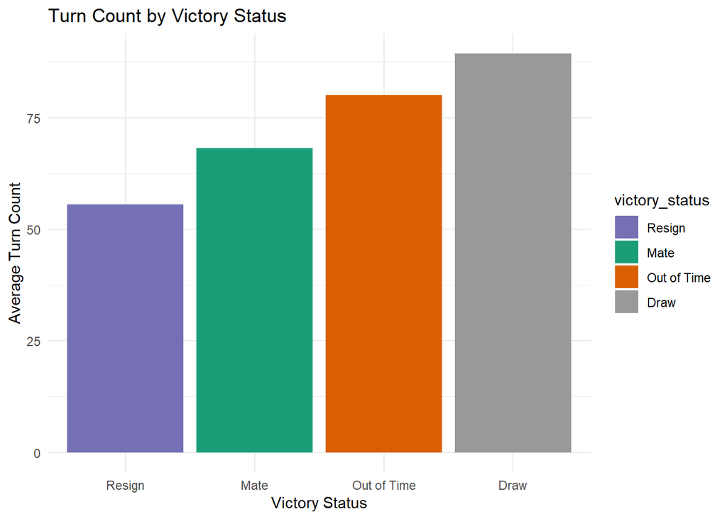